# PAC 2 – Exploració de tècniques de visualització de dades

Eloi Vilella

2025-11-06

[figure not shown]

# 1 Introducció

En aquesta PAC 2 es demana sortir de la zona de confort explorant **tres tècniques de visualització** diferents. L’objectiu és entendre’n **l’origen, el funcionament, els avantatges i limitacions**, i crear una **visualització pròpia** amb dades obertes per a cadascuna.

Les tècniques assignades són:

1. Dot Density Map
2. Circular Dendrogram
3. UpSet Plot

# 2 1. Dot Density Map

## 2.1 Definició i origen

El **Dot Density Map** (o *dot distribution map*) és una tècnica de **cartografia temàtica** que representa la distribució espacial d’un fenomen mitjançant punts. Cada punt representa una ocurrència (o un nombre determinat de casos) dins d’una regió o polígon geogràfic.

Aquesta tècnica té una llarga tradició en la cartografia (més de 150 anys d’ús). Avui s’utilitza àmpliament en GIS i visualització de dades modernes.

[figure not shown]

## 2.2 Funcionament

- Cada punt simbolitza una quantitat determinada d’un fenomen (p. ex. 1 punt = 1 estació).
- Els punts es distribueixen dins d’una àrea, sovint de manera aleatòria o ponderada (per exemple, proporcional a població).
- Zones amb més punts indiquen major concentració; zones amb menys, baixa densitat.
- S’ha d’especificar clarament la **unitat del punt** (què representa cada punt) per evitar interpretacions errònies.

## 2.3 Avantatges

- Visualització **intuitiva** i fàcil d’interpretar per maps de densitat.
- Permet comparar patrons espacials entre regions diferents.
- Pot mostrar múltiples categories utilitzant diferents colors o capes.

## 2.4 Inconvenients

- Amb alt nombre de punts pot resultar **saturat** i perdre informació.
- La generació aleatòria de punts dins polígons pot induir variabilitat (problema de reproducibilitat si no es fixa la llavor).
- Subjecte al MAUP (modifiable areal unit problem): la mida i forma de les unitats administratives afecta la percepció.

## 2.5 Tipus de dades

- Dades geoespacials amb punts o geometries polígon (municipis, comarques, codis postals).
- Variables quantitatives agregades (població, incidents, punts d’interès).

## 2.6 Aplicacions habituals

- Densitat de població, habitatge o serveis.
- Distribució d’infraestructures: estacions de recàrrega, hospitals, escoles.
- Visualització de distribució d’esdeveniments puntuals (accidents, crims, etc.).

## 2.7 Exemple d’aplicació (codi i dades)

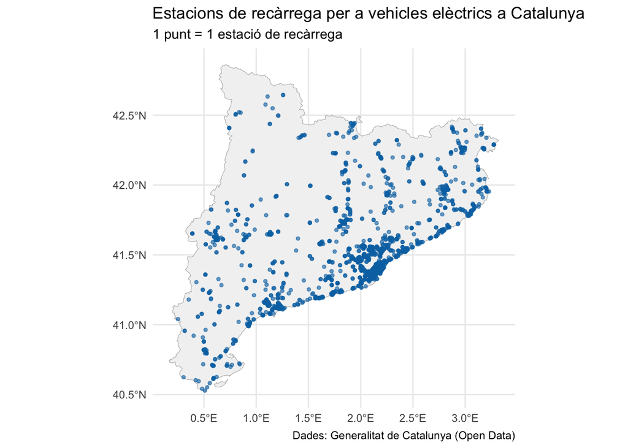

# 3 2. Circular Dendrogram

## 3.1 Definició i origen

El **Circular Dendrogram** (o *Radial Dendrogram*) és una variació del **dendrogram jeràrquic** tradicional en què l’arbre s’organitza de manera radial al voltant d’un eix central. Els dendrograms deriven de tècniques d’**anàlisi jeràrquica** (hierarchical clustering), emprades històricament en disciplines com la biologia i la taxonomia per mostrar relacions de parentesc o similitud.

El format circular es va popularitzar en bioinformàtica i visualització perquè **maximitza l’ús de l’espai** quan hi ha molts terminals (fulles), facilitant la visualització de centenars o milers de fulles sense tallar l’arbre en pàgines llargues.

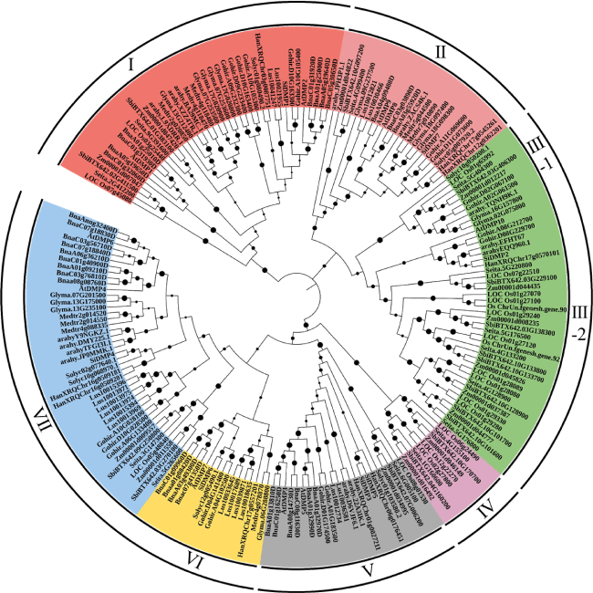

## 3.2 Funcionament

- Partim d’una matriu de distàncies o d’una matriu de similitud entre elements.
- S’aplica un mètode d’agregació jeràrquica (p.ex. **UPGMA**, **Ward**, **single**, **complete**, o **neighbor-joining** en filogenètica).
- El resultat és un arbre (`hclust`, `phylo`) que s’ordena radialment: l’arrel al centre i les fulles al perímetre.
- Les longituds de branca poden representar distàncies (si s’utilitzen mètodes que conserven longituds) o bé només la jerarquia (si `branch.length = "none"`).
- Es poden codificar atributs addicionals en color de branques, gruix, o etiquetes.

## 3.3 Avantatges

- **Ocupa menys espai** vertical que un dendrogram lineal per a molts terminals.
- Millora la percepció de patrons globals i simetries en l’arbre.
- Ideal per integrar metadades (colores en branques, heatmaps externs).

## 3.4 Inconvenients

- Les etiquetes poden ser **difícils de llegir** si hi ha moltes fulles — sovint cal rotar o incloure etiquetes interactives.
- La distància radial no sempre és directa d’interpretar; la comprensió de longituds radial/anglars pot confondre usuaris no tècnics.
- Per a comparacions quantitatives rigoroses entre distàncies, els dendrograms lineals poden ser més clars (sobretot si es necessiten escales legibles).

## 3.5 Tipus de dades

- Dades jeràrquiques o resultats d’agrupament: clustering de gens, espècies, documents, usuaris, etc.
- Matrius de distància (Euclidiana, cosinus, identitat, distàncies evolutives).
- Formats R habituals: objectes `hclust`, `dendrogram`, `phylo`.

## 3.6 Aplicacions habituals

- Filogenètica: arbres evolutius construïts amb mètodes com **neighbor-joining** o **maximum likelihood** (visualització).
- Anàlisi de clustering en ciència de dades: agrupament d’expressions gèniques, patrons de consum, segmentacions.
- Mapes jeràrquics d’organitzacions, taxonomies de categories, visualització de l’estructura d’arbres de decisions.

## 3.7 Exemple d’aplicació (seqüències proteiques)

En l’exemple següent es parteix d’un fitxer FASTA amb seqüències proteiques, es realitza una alineació múltiple, es calcula una matriu de distàncies i es construeix un arbre amb l’algorisme **Neighbor-Joining** (un mètode molt emprat per construcció ràpida d’arbres filogenètics). El gràfic final s’exporta a PNG.

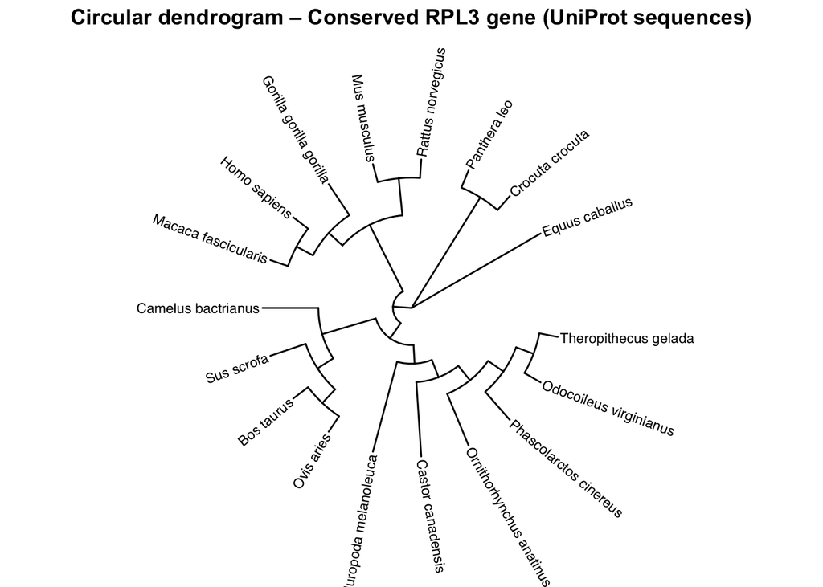

# 4 3. UpSet Plot

## 4.1 Definició i origen

L’**UpSet Plot** és una tècnica per visualitzar **conjunts i les seves interseccions** de manera escalable i quantitativa. Va ser introduïda per **Alexander Lex et al. (2014)** com a alternativa als diagrames de Venn i Euler, que esdevenen difícils de llegir a partir de 3 conjunts o més. L’aplicació és especialment valuosa quan es vol analitzar quantitats d’elements en interseccions específiques i combinar aquesta informació amb metadades.

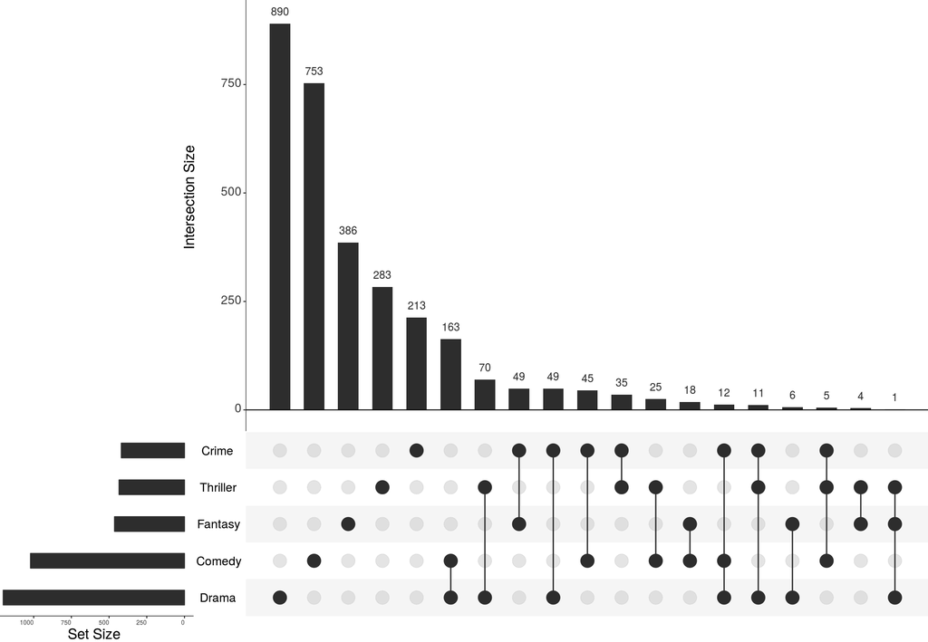

## 4.3 Avantatges

- **Escalable**: funciona bé amb molts conjunts (10+, si cal).
- Mostra clarament **quines interseccions són més freqüents** i la seva mida.
- Permet afegir informació quantitativa addicional (colors, valors laterals).
- És fàcil ordenar les interseccions per mida, proporció o qualsevol mètrica rellevant.

## 4.4 Inconvenients

- Pot ser menys intuïtiu per a usuaris no acostumats a la matriu de punts.
- Amb masses interseccions diferents (p.ex. 2^n molt gran) cal filtrar i agrupar per interpretar les principals.
- Requereix preparar correctament la matriu de presència/absència (neteja i definició de conjunts).

## 4.5 Tipus de dades

- Elements amb pertinença a conjunts (gens en experiments, clients per categories de compra, accidents amb tipus de vehicle, etc.).
- Dades binàries (TRUE/FALSE) per cada conjunt, o convertibles a binari.

## 4.6 Aplicacions habituals

- Genòmica: conjunts de gens diferentsament expressats en condicions múltiples.
- Anàlisi de clients: combinacions de categories de compra.
- Epidemiologia/seguretat: combinacions d’exposicions o factors en incidents.

## 4.7 Exemple d’aplicació (accidents de trànsit)

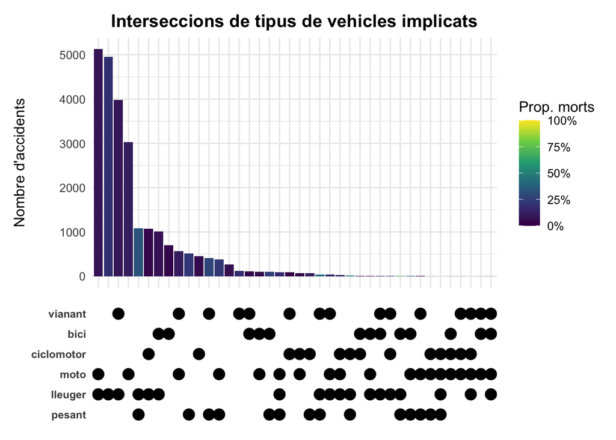